# Red Wine Analysis

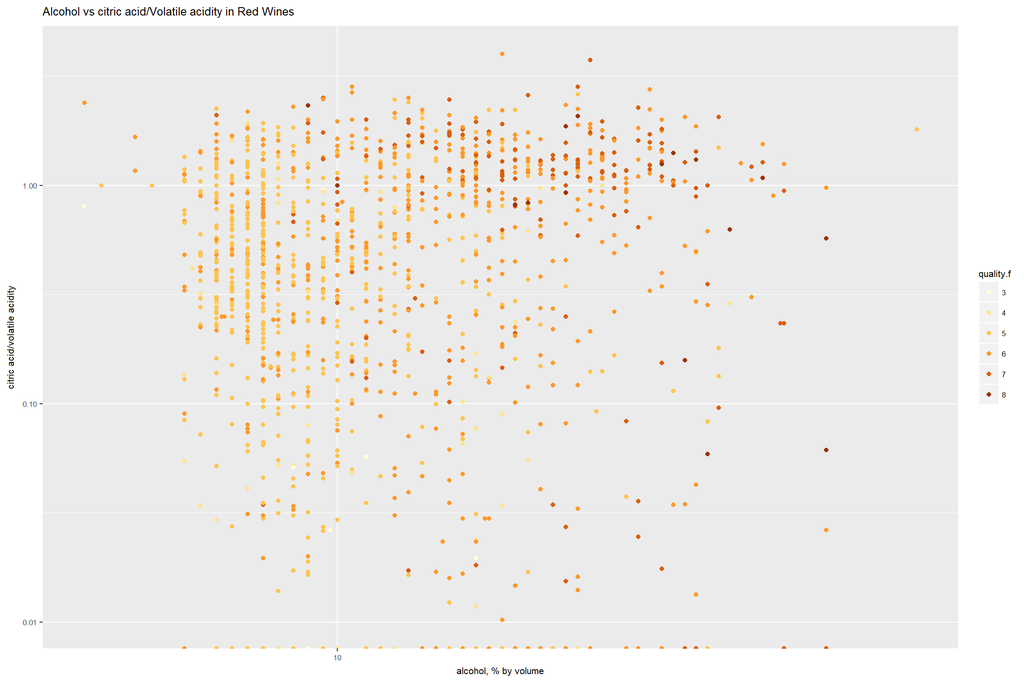

The next several plots look at the strongest correletions between the other input variables: the group of density, fixed acidity, residual sugar seemed of interest as did the group of fixed acidity, free sulfur dioxide, total sulfur dioxide. Before diving into those groups, I wanted to look at quality in relation to density and residual sugar. As a person who enjoys red wine, I have a personal preference for what I describe as a’red whine which is kinda heavy with a touch of sweetness’.

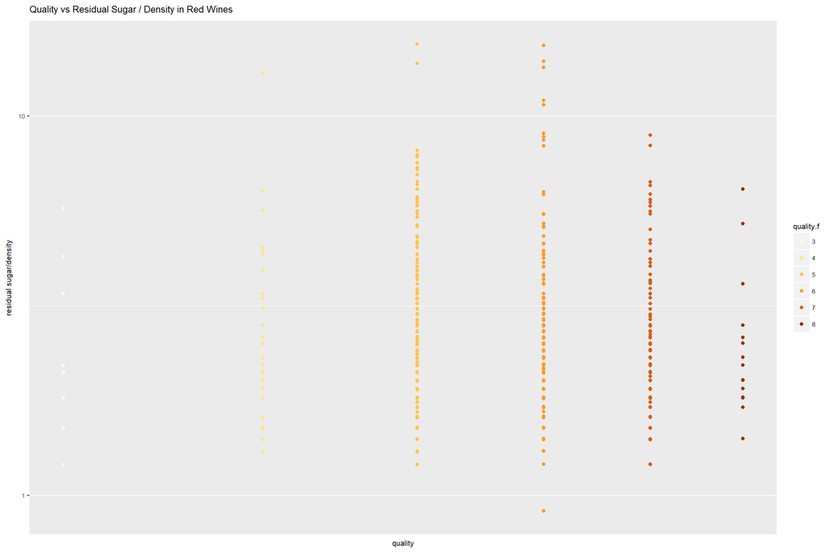

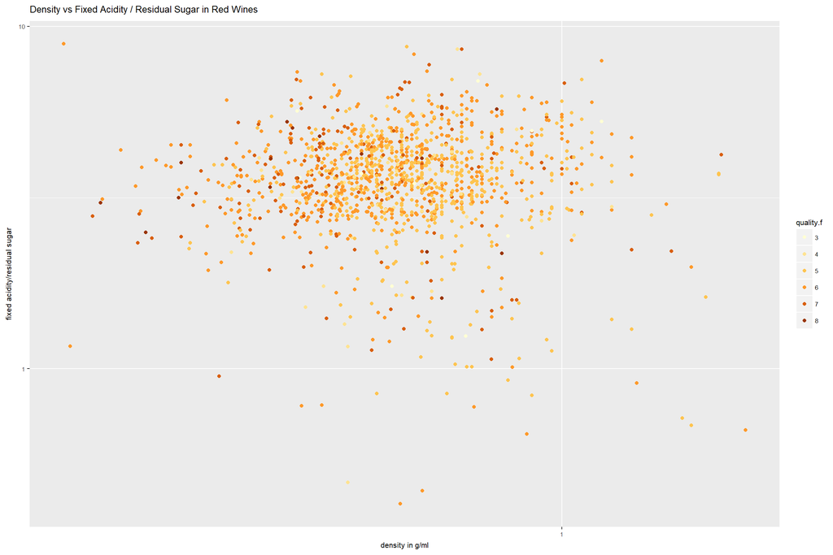

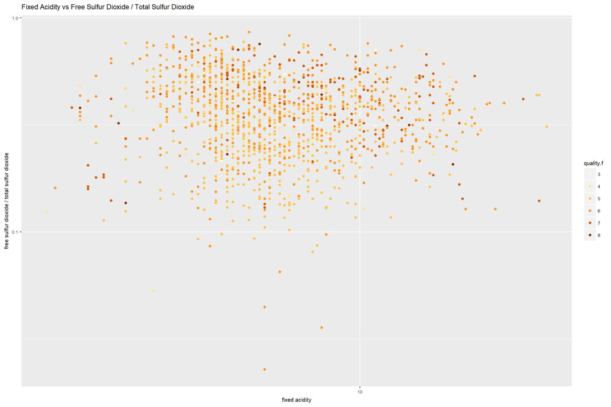

# Multivariate Analysis

## Were there any interesting or surprising interactions between features?

I was suprised that density and residual sugar did not have a stronger influence on quality. Additionally, when I first noted how much alcohol influence quality I was suspect since the quality rating involved human scoring. Very interesting and suprising was the strong influence sulphates have on quality. I personally know some people with small vineyards and want to discuss the sulphate content of their soil.

# Final Plots and Summary

## Description on Plot One

Most of the Red Wines have a Quality rating between 5 and 7.

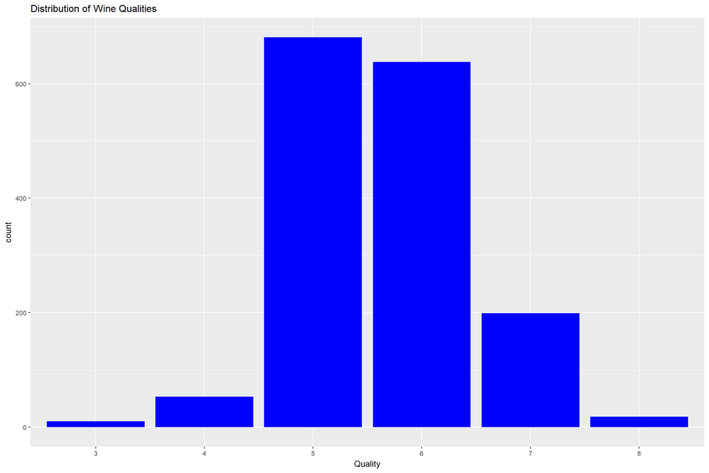

Description Plot Two

Quality ratings for Red Wines increase with increased levels of Alcohol and Sulphates.

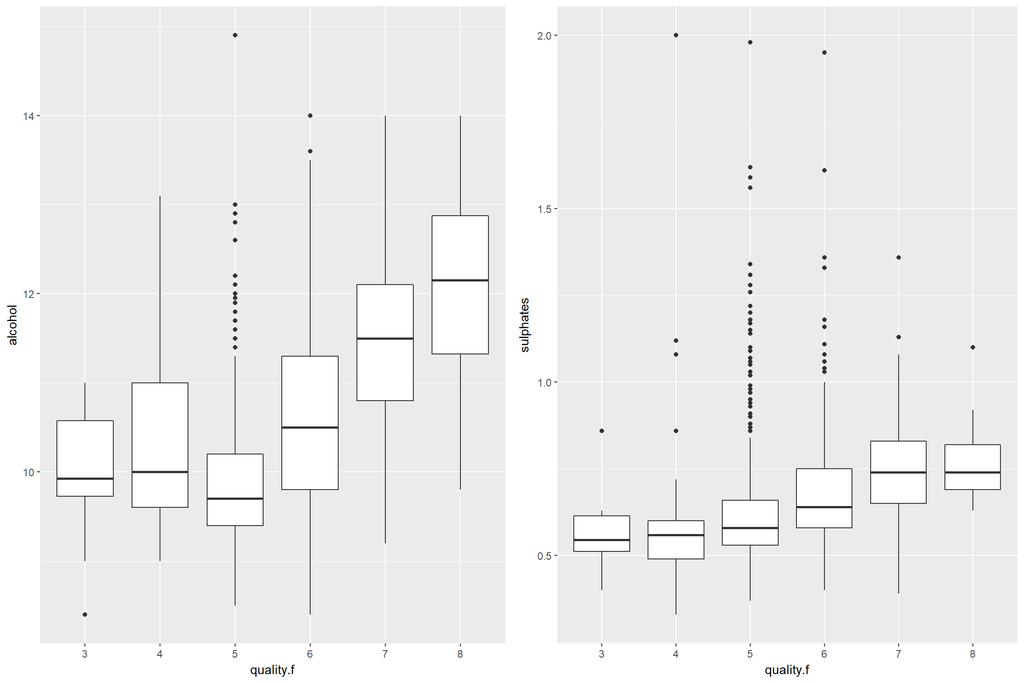

Description Plot Three

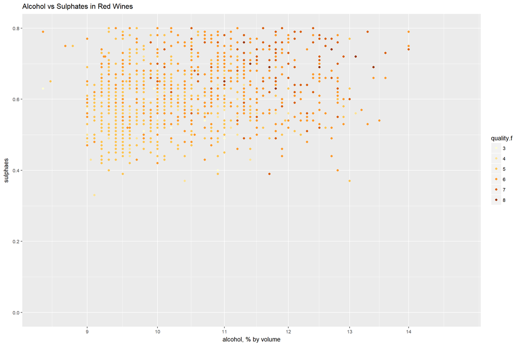

Reflections

Exploratory Data Analysis is a process. Like real life exploring the process goes one step at a time with knowledge building on itself and suggesting the next step. Another similarity is that the process leads not to conclutions (as that is not the purpose) but to insights. Finally, while there may be no definitive end to exploration, one concludes exploration ‘by letting the experience or in this case, the data speak for itself’.

References

P. Cortez, A. Cerdeira, F. Almeida, T. Matos and J. Reis. Modeling wine preferences by data mining from physicochemical properties. In Decision Support Systems, Elsevier, 47(4):547-553. ISSN: 0167-9236.

Factor variables http://statistics.ats.ucla.edu/stat/r/modules/factor_variables.htm

Pair Plots http://sas-and-r.blogspot.com/2011/12/example-917-much-better-pairs-plots.html Adding and removing columns from a data frame http://www.cookbook-r.com/Manipulating_data/Adding_and_removing_columns_from_a_data_frame/

Exploratory data analysis and data http://r4ds.had.co.nz/r-markdown.html#text-formatting-with-markdown

Exploratory Data Analysis on Wine Quality by Bilal Mahmood https://rpubs.com/Bilal_Mahmood/EDA

Wine Quality Analysis: http://rstudio-pubs-static.s3.amazonaws.com/24803_abbae17a5e154b259f6f9225da6dade0.html

Wine Quality Analysis https://github.com/mudspringhiker/exploratory_data_analysis_wines_using_R/blob/master/eda_wines_varshal.Rmd

Correlation matrix http://www.cookbook-r.com/Graphs/Correlation_matrix/

An introduction to corrplot package https://cran.r-project.org/web/packages/corrplot/vignettes/corrplot-intro.html

Diamonds exploration by Chris Saden: https://s3.amazonaws.com/udacity-hosted-downloads/ud651/diamondsExample.html

Knitr with R Markdown http://kbroman.org/knitr_knutshell/pages/Rmarkdown.html